# Project 2

HEXIM 1 is found on Human(Homosapien) chromosome 17 and Mouse(MUS) chromosome 11. It is both a protein and a gene and is also known to interact withe Cyclin T1 and Cdk9.

Homosapien and Mus Mouse are orthologous for the HEXIM 1 gene. Which means that at one point humans and mice were diverged from a common speciation of species and the HEXIM1 at one point in time was the same in this common ancestor. However as evolution has gone on is it possible that HEXIM 1 devaied in function between the two orthologous? Is the protien still similar enough to find out more information of HEXIM 1 to help aid in studies of cancers, AIDS, inflammation and others.

# Scientific Question

Is it possible for Mice HEXIM1 protein be used as a model comparison to study human HEXIM1 protein?

HEXIM 1 in Humans is known to be a transcriptional regulator as a general RNA Poly II transcription inhibitor. Also plays a role in DNA virus mediated innate immune response by assembling into the HDP-RNP complex which is a plateform for IRF3 phosphorylation. "Expression of this gene is induced by hexamethylene-bis-acetamide in vascular smooth muscle cells" website link: https://www.ncbi.nlm.nih.gov/gene/10614

"HEXIM1 HEXIM P-TEFb complex subunit 1" https://www.ncbi.nlm.nih.gov/gene/10614 "Expression of this gene is induced by hexamethylene-bis-acetamide in vascular smooth muscle cells. This gene has no introns."

HEXIM 1 in mouse is a gene and a protein coding gene. "Predicted to enable several functions, including 7SK snRNA binding activity; P-TEFb complex binding activity; and cyclin-dependent protein serine/threonine kinase inhibitor activity. Acts upstream of or within heart development and negative regulation of transcription, DNA-templated. Located in nucleus. Is expressed in several structures, including branchial arch; embryo mesenchyme; heart and pericardium; hindgut dorsal mesentery; and sensory organ. Orthologous to human HEXIM1 (HEXIM P-TEFb complex subunit 1)." https://www.ncbi.nlm.nih.gov/gene/192231

# Hypothesis

If HEXIM 1 protein in Mice is similar in sequence and function then it can be used as a comparison model to study HEXIM1 in humans.

Data for the multiple sequence alignment was found using uniport: https://www.uniprot.org/uniprot/?query=HEXIM+1&sort=score https://www.uniprot.org/uniprot/?query=HEXIM+1&sort=score

(here are some references that iI used while finding the data https://www.proteinatlas.org/ENSG00000186834-HEXIM1/tissue

https://www.ncbi.nlm.nih.gov/datasets/tables/genes/?table_type=transcripts&key=c991c6f01ff36d3a30cc3706fb6daeb6

https://www.ebi.ac.uk/ebisearch/search.ebi?db=atlas-genes-differential&query=HEXIM%201&size=15&facets=TAXONOMY:9606,TAXONOMY:10090)

Swiss protien for strucrual bio informatics and 3D model comparsion then I measured the distance between the stuctures.

# Loading packages

```python
import pandas as pd
import numpy as np
import scipy as scip
import os
from IPython.display import Image
import itertools
import matplotlib.pyplot as plt
import numpy as np
import pandas as pd
import matplotlib.pyplot as plt
from Bio.Align.Applications import ClustalwCommandline
import logomaker
```

```python
conda install -c conda-forge nglview
```

[output not shown]

Pandas:It is used as a tool to help data and machine learning for data clean up and anyalsis. Data can be kept in a more effcent manner to prefrom python tasks. It helps handle missing data. Also provides an efficient way to site. Along with being able to merge, concateate or reshape.

Numpy:Offeres a lot of different uses, such as numerical computing tools and powerdul n-dimensional array. It works a long ray of handwares and and is easy to use. Along with playing well with libraries.

SciPy:Helps provide fundamental algorithms by optimization of intergration, differential equations amd my other types of problems across many domains. By providing specialized data structure. It is easy to used. Also avaible all types of domains.

matplotlib: It is used as a comprehensive library that creats different types of graphical visualations. It is custimiable and able to exported. You can use it for almost all of the type of graphical representation.It is very helpful when interpting datas.

IPython.display: It is part of all frontends where the user can decide when and what type of representation to use and how. You can use to to audio or visuals, etc. This is a display thus it hasn't been alocated a command of representaion thus it is very veristial in use.

# Performing Bioinformatics Analysis

This data was uptained via NCBI of HEXIM1 homosapiens and MEXIM1 (https://www.ncbi.nlm.nih.gov/gene/10614)of MUS(https://www.ncbi.nlm.nih.gov/gene/192231)

> sp|O94992|HEXI1_HUMAN Protein HEXIM1 OS=Homo sapiens OX=9606 GN=HEXIM1 PE=1 SV=1 MAEPFLSEYQHQPQTSNCTGAAAVQEELNPERPPGAEERVPEEDSRWQSRAFPQLGGRPG PEGEGSLESQPPPLQTQACPESSCLREGEKGQNGDDSSAGGDFPPPAEVEPTPEAELLAQ PCHDSEASKLGAPAAGGEEEWGQQQRQLGKKKHRRRPSKKKRHWKPYYKLTWEEKKKFDE KQSLRASRIRAEMFAKGQPVAPYNTTQFLMDDHDQEEPDLKTGLYSKRAAAKSDDTSDDD FMEEGGEEDGGSDGMGGDGSEFLQRDFSETYERYHTESLQNMSKQELIKEYLELEKCLSR MEDENNRLRLESKRLGGDDARVRELELELDRLRAENLQLLTENELHRQQERAPLSKFGD sp|Q8R409|HEXI1_MOUSE Protein HEXIM1 OS=Mus musculus OX=10090 GN=Hexim1 PE=1 SV=1 MAEPLLTEHQHQPQTSNCTGAAVVHEEHTSERPPSAEERVPKEDSRWQSRASLQSGSRPG QEGEGGLKHQLPPLQTNACPELSSLEKGEKGQNGEDLSTGGASPSAEGEPMSESLVQPGH DSEATKQEAPAAGGEEPWGQQQRQLGKKKHRRRPSKKKRHWKPYYKLTWEEKKKFDEKQS LRASRVRAEMFAKGQPVAPYNTTQFLMDDHDQEEPDLKTGLYPKRAAAKSDDTSDEDFVE EAGEEDGGSDGMGGDGSEFLQRDFSETYERYHAESLQNMSKQELIKEYLELEKCLSRKED ENNRLRLESKRLGGVDARVRELELELDRLRAENLQLLTENELHRQQERAPLSKFGD

```python
#downloaded protien and do a sequences alignment for protiens
# This is single sequence alignment
from Bio import AlignIO
alignmenthuman = AlignIO.read("protein.faa", "fasta")


from Bio import AlignIO
alignmentmouse = AlignIO.read("proteinmouse.faa", "fasta")
```

```python
print(alignmenthuman)
```

```
Alignment with 1 rows and 359 columns
MAEPFLSEYQHQPQTSNCTGAAAVQEELNPERPPGAEERVPEED...FGD NP_006451.1
```

```python
print(alignmentmouse)
```

```
Alignment with 1 rows and 356 columns
MAEPLLTEHQHQPQTSNCTGAAVVHEEHTSERPPSAEERVPKED...FGD NP_620092.1
```

```python
#aligning both sequences with phylip
#data from https://www.ncbi.nlm.nih.gov/tools/cobalt/cobalt.cgi
from Bio import AlignIO
alignments = AlignIO.parse("92F15ZRM212-alignment.phylip", "phylip")
for alignment in alignments:
    print(alignment)
    print("")
```

```
Alignment with 2 rows and 360 columns
MAEPLLTEHQHQPQTSNCTGAAVVHEEHTSERPPSAEERVPKED...FGD protein_H
MAEPFLSEYQHQPQTSNCTGAAAVQEELNPERPPGAEERVPEED...FGD protein_H
```

```python
pip install logomaker
```

my reference https://biopython-tutorial.readthedocs.io/en/latest/notebooks/14%20-%20Sequence%20motif%20analysis%20using%20Bio.motifs.html

```python
#This was my first try at making a sequence logo however I could not get it to run
# I used Sequence Logos
#from Bio import motifs
#from Bio.Seq import Seq
#instances = [Seq("AGCAG"),
  #  Seq("GAGGA"),
#   ]

#m = motifs.create(instances)

#print(m)
#print(m.counts)
#how do I insert the photo
#m.weblogo("GAG.png")
#m.weblogo("AGC.png")
```

[output not shown]

https://github.com/jbkinney/logomaker/blob/master/logomaker/tutorials/7_load_data_from_files.ipynb

This is the reference code that I used to make a nucleotide aligment.

```python
#making logo for the nucleotide sequences of protien HEXIM 1 iin MUS and HomoSapiens
import numpy as np
import pandas as pd
import matplotlib.pyplot as plt
%matplotlib inline
plt.ion()

import logomaker as lm
```

The final tree fasta file has the sequence alignement of the protien of the two subjects. This is done with the whole DNA sequence of the protien

```python
crp_sites_df = pd.read_csv('input.fa.final_tree.fa', comment='>', names=['site'])
crp_sites_df.head()
```

|  | site |
| --- | --- |
| 0 | AGCAGTTGGAAGTTGGCAGGTGGAGAGGCAGGTTGGGAGGGAAAGT... |
| 1 | ----------------------------------------------... |

```python
crp_sites_list = crp_sites_df['site'].values
crp_sites_list[:1]
```

[output not shown]

```
<logomaker.src.Logo.Logo at 0x7fcb3bb84190>
```

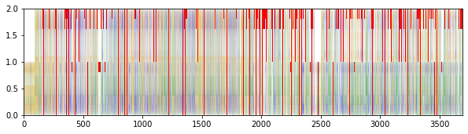

```python
crp_counts_df =logomaker.alignment_to_matrix(sequences=crp_sites_list, to_type='counts')
logomaker.Logo(crp_counts_df)
```

```python
crp_sites_d = pd.read_csv('input.fa.final_tree_small.fa', comment='>', names=['sites'])
crp_sites_d.head()
```

|  | sites |
| --- | --- |
| 0 | GAGGAA- |
| 1 | -AGCAGT |

```python
crp_sites_lists = crp_sites_d['sites'].values
crp_sites_lists[:2]
```

```
array(['GAGGAA-', '-AGCAGT'], dtype=object)
```

```
<logomaker.src.Logo.Logo at 0x7fcb13fa3df0>
```

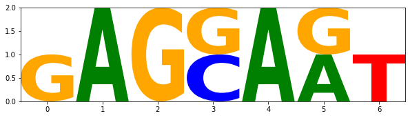

```python
crp_counts_d =logomaker.alignment_to_matrix(sequences=crp_sites_lists, to_type='counts')
logomaker.Logo(crp_counts_d)
```

P-TEFb complex in both Humans and mice. It is part of boths binding acitivty however it is notied that it does assoicate with HEXIM1 . "Hexim1 is a cellular protein that associates with the positive transcription elongation factor b (P-TEFb) to regulate RNA polymerase II elongation of nascent mRNA transcripts." https://www.rcsb.org/structure/2GD7 In Homo sapiens. while in mice "Brd4 is a member of the bromodomains and extra terminal domain (BET) family of proteins that recognize acetylated chromatin structures through their bromodomains and act as transcriptional activators. Brd4 functions as an associated factor and positive regulator of P-TEFb, a Cdk9-cyclin T heterodimer that stimulates transcriptional elongation by RNA polymerase II."https://www.rcsb.org/structure/3JVK

```python
from Bio.PDB import *
```

Total Structure Weight: 25.36 kDa Atom Count: 1774 Modelled Residue Count: 214 Deposited Residue Count: 214 Unique protein chains: 1 2GD7 The Structure of the Cyclin T-binding domain of Hexim1 reveals the molecular basis for regulation of transcription elongation https://www.rcsb.org/structure/2GD7

```python
import nglview
view = nglview.show_pdbid("2GD7")  # load "2GD7" from RCSB PDB and display viewer widget
view.add_representation('licorice', selection='chain A')
view
```

```python
import numpy
from Bio.PDB.PDBParser import PDBParser
parser = PDBParser()
structure = parser.get_structure("2GD7", "2GD7.pdb")
```

```python
residues = [r for r in structure.get_residues()]
one  = residues[0]["CA"].get_coord()
two = residues[1]["CA"].get_coord()
print('{} - {} = {}'.format(one,two, numpy.linalg.norm(one-two)))
```

```
[109.813  -0.369   3.914] - [111.283   0.596   0.492] = 3.8473613262176514
```

3JVK Crystal structure of bromodomain 1 of mouse Brd4 in complex with histone H3-K(ac)14.Brd4 functions as an associated factor and positive regulator of P-TEFb, a Cdk9-cyclin T heterodimer that stimulates transcriptional elongation by RNA polymerase II. https://www.rcsb.org/structure/3JVK

```python
from Bio.PDB import *
import nglview as nv

view = nv.show_biopython(structure)
view
parser = PDBParser()
```

```python
import nglview
view = nglview.show_pdbid("3JVK")    # load "3JVK" from RCSB PDB and display viewer widget
view.add_representation('licorice', selection='chain A')
view
```

```python
import numpy
from Bio.PDB.PDBParser import PDBParser
parser = PDBParser()
structure = parser.get_structure("3JVK", "3JVK.pdb")
```

```python
residues = [r for r in structure.get_residues()]
one  = residues[0]["CB"].get_coord()
two = residues[1]["CB"].get_coord()
print('{} - {} = {}'.format(one,two, numpy.linalg.norm(one-two)))
```

```
[ 15.361 -20.839   3.231] - [ 15.523 -26.001   5.167] = 5.515484809875488
```

# Analysis of the results

When reasearching the HEXIM 1 in humans it was found to be a transcription regulator and aided in innate immune response. However in mouse mus it was found that P-TEFb is a postitve transcription regulator that will enlongae the transcirption regulator.

# Questions

I looked at mutiple data bases but I can't find any data to make a RNA sequesnce anaylis then make a heat map. So I had to change my orginal plan. What do you suggest I do to proove that HEXIM 1 has a different function in both humans and mice?

When will there be more data bases available to bettere understand HEXIM 1 in humans ?